# Healthy Relationship Notebook

[output not shown]

```
[1] 4.418898
[1] 496
[1] 844
[1] "58.77%"
```

```
61.09%
```

# Healthy Relationship Outcome

Relationship skills are a critical component of success in all realms of life. The Healthy Relationship questions measures the behaviors and attitudes of the respondent regarding their relationship skills. Questions that measure healthy relationships skills include the following:

*Healthy Relationship Questions*

1. If I have a serious problem, I have people to talk with.
2. I let people know if they have hurt my feelings.
3. I let my friends know when I think they are good at something.
4. In any relationship - romantic or not - I make it clear when I don’t feel comfortable.

## Pre Survey Analysis

```
[1] 3.85
```

The number of valid surveys entered is **568**, and the number of students achieving at a high level is **210** and that equates to **36.97%**. The average score from students is **3.85**

# Pre Survey Healthy Relationship History

```
---------------------------------------------
 Year   population   percent_achieved   mean
------ ------------ ------------------ ------
 2013      699             61%          4.55

 2014      1186            61%          4.44

 2015      844             59%          4.41
---------------------------------------------
```

Cross Validation of Healthy Relationship Skills

# Pre Parent Survey

Question 5: She develops positive relationships with her classmates.

Results based on responses.

|  | Item | low | neutral | high | mean | sd |
| --- | --- | --- | --- | --- | --- | --- |
| 1 | Q5 | 7.337526 | 20.75472 | 71.90776 | 5.218029 | 1.338917 |

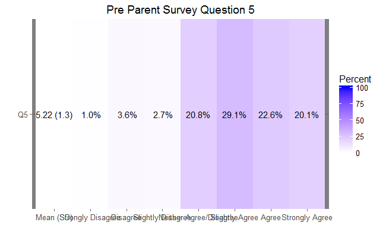

### Teacher Survey

```
----------------------------------------------------------------
 Agree   Disagree   Neither Agree nor Disagree   Slightly Agree
------- ---------- ---------------------------- ----------------
  52        8                  100                    104
----------------------------------------------------------------

Table: Table continues below


--------------------------------------------------------
 Slightly Disagree   Strongly Agree   Strongly Disagree
------------------- ---------------- -------------------
        26                 31                 5
--------------------------------------------------------
```

|  | Item | low | neutral | high | mean | sd |
| --- | --- | --- | --- | --- | --- | --- |
| 1 | Q7 | 11.96319 | 30.67485 | 57.36196 | 4.748466 | 1.254376 |

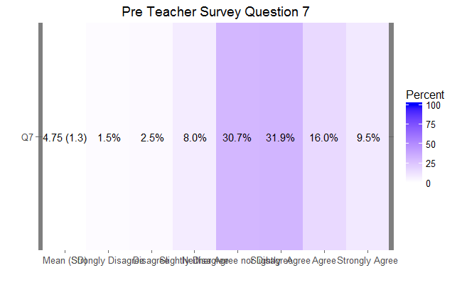